# MACHINE LEARNING FOR SURVEY RESEARCH II

Detecting Response Styles

Marco R. Steenbergen

steenbergen@ipz.uzh.ch

University of Zurich

August 19, 2026

## Where we are going

1. **Response styles** — what they are, and why you should care
2. **Counting them** — the classical indices, and why they fail
3. **A short IRT detour** — the machinery we need
4. **IRTree models** — decomposing a rating into decisions
5. **Where machine learning comes in** — partitioning, mixtures, clustering
6. **Code** — the ESS institutional-trust battery, end to end

# What is a response style?

## Two respondents, same opinion

How much do you trust … *(0 = not at all, 10 = complete trust)*

| Institution | Anna | Bruno |
| --- | --- | --- |
| Parliament | 8 | 10 |
| Legal system | 7 | 10 |
| Police | 8 | 10 |
| Politicians | 6 | 5 |
| Political parties | 6 | 5 |
| European Parliament | 7 | 10 |
| United Nations | 8 | 10 |
| **Mean** | **7.1** | **8.6** |

Is Bruno really more trusting? Or does he just *use the scale differently*?

## The definition

> A **response style** is a systematic tendency to use the response categories of a rating scale in a particular way, **independently of the item content**.

Two claims are packed in here, and both are testable:

- **Systematic** — it recurs across items, not a one-off slip
- **Content-independent** — it would show up on a scale about anything

Contrast with a **response set** (situational, e.g. faking on one questionnaire) and with **satisficing** (a shortcut taken under load).

# The zoo

| Style | Behaviour | On a 0–10 scale |
| --- | --- | --- |
| **ERS** | Extreme response style | Overuse of 0 and 10 |
| **MRS** | Midpoint / middle response style | Overuse of 5 |
| **ARS** | Acquiescence | Agreeing regardless of content |
| **DARS** | Disacquiescence | Disagreeing regardless of content |
| **NCR** | Non-contingent responding | Random / careless answers |
| **RR** | Response range | Narrow vs. wide use of the scale |

The ESS trust battery has no reverse-worded items, so **ARS is not identified here**. This is a design problem, not a modelling problem (Kam 2016).

## Why bother? I—Means *and* correlations move

**Means and rankings.** Styles shift the observed mean away from the true one, by different amounts in different groups. Country A uses endpoints more than country B; A now looks more trusting — or less — depending on where its true mean sits relative to the midpoint (Baumgartner and Steenkamp 2001).

**Correlations.** A style is a shared source of variance across every item on the scale. Two scales measured on the same respondents share it, so their correlation is **inflated** or **attenuated** depending on the proportion of reverse-worded items and the distance of the scale mean from the midpoint. Neither is under your control after data collection.

Ulitzsch et al. (2024): scale-usage differences are **ubiquitous** in cross-country comparisons and can manufacture or mask substantive relationships. For the ESS this is not a footnote — it is the core inferential risk of the comparative enterprise.

## Why bother? II—Measurement invariance

Cross-national comparison rests on **invariance**: the same latent construct, measured the same way, in every country.

A response style violates this at the level of **thresholds**—where people place the cut-points between categories—while leaving the factor loadings roughly intact.

This is exactly the pattern that shows up in the ESS comparability literature (Davidov et al. 2015). The acquiescence-modelling tradition in European survey research (Billiet and McClendon 2000; Billiet and Davidov 2008) is the direct ancestor of what we do today.

## Are response styles traits?

Two literatures, two answers.

**Yes — they are stable**

- Stable across scales within a session (Weijters et al. 2010)
- Stable over **8 years** (Wetzel et al. 2016)
- Correlated with education, age, culture (He et al. 2014)

**No — not really**

Ames (2022), three unrelated scales, same respondents:

- ERS across scales: *r* = .38 – .58
- A single shared ERS trait fits **much worse** (DIC 25,344 vs 19,911)
- 5-point items produced 25–46% extreme responses; 4-point items only 8%

**Read this as:** styles are person × instrument, not person alone.

# Counting—the Classical Baseline

## The indices

Simple, transparent, computable in one line (Greenleaf 1992; Baumgartner and Steenkamp 2001).

```r
ERS = proportion of responses in {0, 10}
MRS = proportion of responses equal to 5
ARS = proportion of responses in {6, ..., 10}
RR  = max(response) - min(response)   within person
```

Always compute these. They are the honest baseline any model has to beat, and they catch data-collection disasters that a latent-variable model will quietly absorb.

## Problem 1—the confound

Run the data generator with the extremity dimension **switched off**. Nobody in this population differs in extreme response style.

```r
theta0 <- cbind(trust = ess$true_trust, mrs = ess$true_mrs, ers = 0)
X0     <- ess_engine(theta0)
idx0   <- style_indices(X0)

sd(idx0$ERS)                      # 0.15
cor(idx0$ERS, abs(idx0$M - 5))    # 0.23
```

The index produces **an SD of 0.15 of “extreme response style”** in a population that has none. Someone who genuinely distrusts every institution answers 0 seven times—and scores as a textbook extreme responder.

```r
tapply(idx0$ERS, cut(idx0$M, quantile(idx0$M, 0:3/3), include.lowest = TRUE), mean)
```

```
#>  [0.43,3.86]  (3.86,5.43]  (5.43,9.57]
#>        0.198        0.154        0.188      <- U-shaped: both tails look "extreme"
```

**This is the whole argument for model-based approaches, in one table.** You cannot subtract the trait out of a count, because the count *is* partly the trait.

## Problems 2 and 3

**2 — Where do you draw the line?**

```r
idx_wide <- style_indices(X, extreme = c(0, 1, 9, 10))
cor(idx$ERS, idx_wide$ERS, method = "spearman")   # 0.64
```

A defensible alternative definition reshuffles a third of your rank ordering.

**3 — No uncertainty.** Seven items give you a proportion out of seven. There is no standard error, no shrinkage toward the mean, no way for the estimate to say “I don’t know”. Every downstream analysis treats it as measured without error.

# A Short Detour into IRT

## IRT in one slide: the binary case

The indices conflate two things. IRT gives us the vocabulary to write them down **separately**: a person parameter **θ**, and **item parameters** that translate θ into a response. Once you have that split, “response style” has a natural home — it is a property of how the person maps θ onto categories, not of θ itself.

For a yes/no item, the two-parameter logistic model:

$$P(X_{ij} = 1 \mid \theta_i) = \frac{\exp\left[a_j(\theta_i - b_j)\right]}{1 + \exp\left[a_j(\theta_i - b_j)\right]}$$

- $\theta_i$ — person $i$’s latent trait
- $b_j$ — item **difficulty** / location: the θ at which $P = .5$
- $a_j$ — item **discrimination**: how steeply the curve rises

That is a logistic regression where the predictor is unobserved and estimated from the pattern of responses across items. Everything else is bookkeeping.

## From binary to ordinal: thresholds

An 11-category item needs **10 boundaries**. Two standard families:

**Graded response model**

Cumulative: $P(X \geq k \mid \theta)$

Each threshold $b_{jk}$ is the θ at which you become more likely than not to answer *at least* $k$.

**Partial credit model**

Adjacent: $P(X = k \mid X \in \{k-1, k\})$

Each threshold is a local comparison between neighbouring categories.

Both are **“divide-by-total”** models: the category probability is one exponential term divided by the sum over all categories.

## The key insight

A response style is a difference in **threshold placement**, not in θ. Same item, same trait — only the thresholds (▲) move.

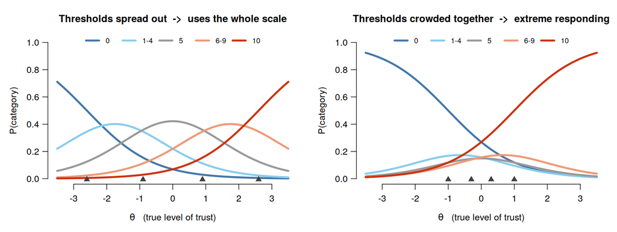

Crowd them together and the endpoints swallow the scale: **extreme responding**.

So: make the thresholds a **function of a second latent variable** and you have a response-style model. That single idea generates most of the literature.

## Two families of response-style model

### Divide-by-total

Keep one equation per category, add style dimensions to it.

- Multidimensional PCM / NRM
- Random-threshold models
- **MNRM** (Bolt and Johnson 2009; Falk and Cai 2016)

Map of the family: Henninger and Meiser (2020a), Henninger and Meiser (2020b)

### Sequential / tree

Break the response into a **sequence of binary decisions**, one latent variable per decision.

- **IRTree** (Böckenholt 2012, 2017)
- Boeck and Partchev (2012); Jeon and De Boeck (2016)

Tutorial comparing both: Böckenholt and Meiser (2017)

They are not rivals so much as different **stories about the response process**. Pick the one whose story you are willing to defend.

# IRTree Models

## The idea, and the classic tree

Stop treating a rating as a single draw from an 11-category distribution. Treat it as the **endpoint of a path** through a small decision tree — each node a binary choice, each node with its own latent variable (Böckenholt 2017):

[figure not shown]

Five terminal nodes, three latent dimensions. Content and style are now **separate equations with separate person parameters** — no subtracting one from the other after the fact.

## Pseudo-items: the actual recoding

Each node becomes a **binary pseudo-item**. `NA` marks decisions the respondent never faced — this is *structural*, not missing data.

| Response | M | D | E |
| --- | --- | --- | --- |
| 1 (strongly disagree) | 0 | 0 | 1 |
| 2 (disagree) | 0 | 0 | 0 |
| 3 (neither) | **1** | NA | NA |
| 4 (agree) | 0 | 1 | 0 |
| 5 (strongly agree) | 0 | 1 | 1 |

One 5-category item becomes three binary items. Seven items become 21.

## Estimation: it is just a multidimensional IRT model

Once recoded, an IRTree is a **multidimensional binary IRT model on the pseudo-items**, with each pseudo-item loading on exactly one dimension.

Two equivalent routes:

**As an MIRT model** — `mirt`

```r
spec <- mirt.model("
  MRS   = 1-7
  TRUST = 8-14
  ERS   = 15-21
  COV = MRS*TRUST, MRS*ERS, TRUST*ERS")
mirt(P, spec, itemtype = "2PL")
```

**As a GLMM** — `lme4` + `irtrees`

```r
long <- dendrify(X, mapping)
glmer(value ~ 0 + sub +
        (0 + sub | person) +
        (0 + node | item),
      long, family = binomial)
```

(Boeck and Partchev 2012)

## Our problem: the ESS scale has 11 points

The IRTree literature is built on **4–7 category** scales. Pokropek et al. (2023) are explicit:

> “Decomposing scales with higher, and in some situations lower, numbers of categories is possible but requires some additional consideration and research on the processes behind the decomposition.”

There is **no validated IRTree specification for an 11-point scale**. So we make the collapse an explicit, declared modelling decision — and then test how much it matters.

## Our tree for the ESS trust items

Collapse first: `0` · `1–4` · `5` · `6–9` · `10` — endpoint, inner, midpoint, inner, endpoint.

[figure not shown]

## Model in R

```r
library(rio)
library(tidyverse)
ess <- import("../data/ESS11e04_2.sav")
ess_ch <- ess |>
  filter(cntry=="CH") |>
  select(trstprl,trstlgl,trstplc, trstplt, trstprt, trstep,
         trstun)
```

## Caveat 1 — recovery degrades down the tree

Alarcon et al. (2023), Monte Carlo, 5-point MPP tree, N = 500–5,000, 10–20 items:

| Node | Mean RMSE (discrimination) | Mean RMSE (difficulty) |
| --- | --- | --- |
| Midpoint (1st) | 0.13 | 0.09 |
| Agreement (2nd) | 0.42 | 0.93 |
| Extreme (3rd) | **0.94** | **3.13** |

“Node” accounted for **81%** of the variance in difficulty RMSE — sample size for essentially none. Yet reported standard errors stayed at 0.00–0.03.

**The model looks confident while being badly wrong at the deepest node.**

## Caveat 2 — not everyone runs the same process

Kim and Bolt (2021) fit a **mixture** IRTree: some respondents’ extreme answers reflect a style, others’ reflect a genuinely extreme opinion.

- TIMSS application: **32% ERS class, 68% ordinal class**
- A single-class model’s 95% credible intervals covered the truth only **68.8%** of the time — badly overconfident

Merhof and Meiser (2023) push further: the process invoked can vary *within* person across nodes. Merhof et al. (2024) show trait and ERS estimates can **mimic** each other, which is a direct threat to interpreting either.

## Caveat 3 — item-specific factors

Lyu et al. (2023): sequential/IRTree models assume the stages within an item are conditionally independent given θ. If there is an **item-specific person factor** η that persists across stages, that assumption fails.

- With sd(η) = 2, estimated discrimination fell from 2.00 at stage 1 to **0.38** at stage 4 — with *constant* true parameters
- Empirically, TIMSS maths: mean $a_1$ = 1.75 vs $a_2$ = 0.96

The declining-discrimination pattern you see across nodes may be an artefact of the model, not a finding about the response process.

## Where this leaves us

**The honest summary of five papers**

All five converge on one point: **IRTree models assume a homogeneous, node-invariant response process, and that assumption is fragile.**

- Lyu et al. (2023) — unmodelled item-specific factors distort node parameters
- Kim and Bolt (2021), Debelak et al. (2025) — the process differs across people
- Ames (2022) — styles are not even stable across scales for one person
- Alarcon et al. (2023) — deep nodes are intrinsically noisy regardless

This is not a reason to abandon IRTree. It is a reason to **test the assumption** — which is precisely where machine learning earns its keep.

## References

Alarcon, Gene M., Michael A. Lee, and Dexter Johnson. 2023. “A Monte Carlo Study of Irtree Models’ Ability to Recover Item Parameters.” *Frontiers in Psychology* 14 (March): 1003756. https://doi.org/10.3389/fpsyg.2023.1003756.

Ames, Allison J. 2022. “Measuring Response Style Stability Across Constructs With Item Response Trees.” *Educational and Psychological Measurement* 82 (2): 281–306. https://doi.org/10.1177/00131644211020103.

Baumgartner, Hans, and Jan-Benedict E. M. Steenkamp. 2001. “Response Styles in Marketing Research: A Cross-National Investigation.” *Journal of Marketing Research* 38 (2): 143–56. https://doi.org/10.1509/jmkr.38.2.143.18840.

Billiet, Jaak B., and Eldad Davidov. 2008. “Testing the Stability of an Acquiescence Style Factor Behind Two Interrelated Substantive Variables in a Panel Design.” *Sociological Methods & Research* 36 (4): 542–62. https://doi.org/10.1177/0049124107313901.

Billiet, Jaak B., and McKee J. McClendon. 2000. “Modeling Acquiescence in Measurement Models for Two Balanced Sets of Items.” *Structural Equation Modeling: A Multidisciplinary Journal* 7 (4): 608–28. https://doi.org/10.1207/S15328007SEM0704_5.

Böckenholt, Ulf. 2012. “Modeling Multiple Response Processes in Judgment and Choice.” *Psychological Methods* 17 (4): 665–78. https://doi.org/10.1037/a0028111.

Böckenholt, Ulf. 2017. “Measuring Response Styles in Likert Items.” *Psychological Methods* 22 (1): 69–83. https://doi.org/10.1037/met0000106.

Böckenholt, Ulf, and Thorsten Meiser. 2017. “Response Style Analysis with Threshold and Multi‐Process IRT Models: A Review and Tutorial.” *British Journal of Mathematical and Statistical Psychology* 70 (1): 159–81. https://doi.org/10.1111/bmsp.12086.

Boeck, Paul De, and Ivailo Partchev. 2012. “IRTrees: Tree-Based Item Response Models of the GLMM Family.” *Journal of Statistical Software* 48. https://doi.org/10.18637/jss.v048.c01.

Bolt, Daniel M., and Timothy R. Johnson. 2009. “Addressing Score Bias and Differential Item Functioning Due to Individual Differences in Response Style.” *Applied Psychological Measurement* 33 (5): 335–52. https://doi.org/10.1177/0146621608329891.

Davidov, Eldad, Jan Cieciuch, Bart Meuleman, Peter Schmidt, René Algesheimer, and Mirjam Hausherr. 2015. “The Comparability of Measurements of Attitudes Toward Immigration in the European Social Survey.” *Public Opinion Quarterly* 79 (S1): 244–66. https://doi.org/10.1093/poq/nfv008.

Debelak, Rudolf, Thorsten Meiser, and Alicia Gernand. 2025. “Investigating Heterogeneity in IRTree Models for Multiple Response Processes with Score‐Based Partitioning.” *British Journal of Mathematical and Statistical Psychology* 78 (2): 420–39. https://doi.org/10.1111/bmsp.12367.

Falk, Carl F., and Li Cai. 2016. “A Flexible Full-Information Approach to the Modeling of Response Styles.” *Psychological Methods* 21 (3): 328–47. https://doi.org/10.1037/met0000059.

Greenleaf, Eric A. 1992. “Measuring Extreme Response Style.” *Public Opinion Quarterly* 56 (3): 328. https://doi.org/10.1086/269326.

He, Jia, Fons Jr Van De Vijver, Alejandra Dominguez Espinosa, and Phoebe Hc Mui. 2014. “Toward a Unification of Acquiescent, Extreme, and Midpoint Response Styles: A Multilevel Study.” *International Journal of Cross Cultural Management* 14 (3): 306–22. https://doi.org/10.1177/1470595814541424.

Henninger, Mirka, and Thorsten Meiser. 2020a. “Different Approaches to Modeling Response Styles in Divide-by-Total Item Response Theory Models (Part 1): A Model Integration.” *Psychological Methods* 25 (5): 560–76. https://doi.org/10.1037/met0000249.

Henninger, Mirka, and Thorsten Meiser. 2020b. “Different Approaches to Modeling Response Styles in Divide-by-Total Item Response Theory Models (Part 2): Applications and Novel Extensions.” *Psychological Methods* 25 (5): 577–95. https://doi.org/10.1037/met0000268.

Jeon, Minjeong, and Paul De Boeck. 2016. “A Generalized Item Response Tree Model for Psychological Assessments.” *Behavior Research Methods* 48 (3): 1070–85. https://doi.org/10.3758/s13428-015-0631-y.

Kam, Chester Chun Seng. 2016. “Further Considerations in Using Items With Diverse Content to Measure Acquiescence.” *Educational and Psychological Measurement* 76 (1): 164–74. https://doi.org/10.1177/0013164415586831.

Kim, Nana, and Daniel M. Bolt. 2021. “A Mixture IRTree Model for Extreme Response Style: Accounting for Response Process Uncertainty.” *Educational and Psychological Measurement* 81 (1): 131–54. https://doi.org/10.1177/0013164420913915.

Lyu, Weicong, Daniel M. Bolt, and Samuel Westby. 2023. “Exploring the Effects of Item-Specific Factors in Sequential and IRTree Models.” *Psychometrika* 88 (3): 745–75. https://doi.org/10.1007/s11336-023-09912-x.

Merhof, Viola, Caroline M. Böhm, and Thorsten Meiser. 2024. “Separation of Traits and Extreme Response Style in IRTree Models: The Role of Mimicry Effects for the Meaningful Interpretation of Estimates.” *Educational and Psychological Measurement* 84 (5): 927–56. https://doi.org/10.1177/00131644231213319.

Merhof, Viola, and Thorsten Meiser. 2023. “Dynamic Response Strategies: Accounting for Response Process Heterogeneity in IRTree Decision Nodes.” *Psychometrika* 88 (4): 1354–80. https://doi.org/10.1007/s11336-023-09901-0.

Pokropek, Artur, Lale Khorramdel, and Matthias von Davier. 2023. “Detecting and Differentiating Extreme and Midpoint Response Styles in Rating Scales Using Tree-Based Item Response Models: Simulation Study and Empirical Evidence.” *Psychological Test and Assessment Modeling* 65 (2): 220–58.

Ulitzsch, Esther, Mirka Henninger, and Thorsten Meiser. 2024. “Differences in Response-Scale Usage Are Ubiquitous in Cross-Country Comparisons and a Potential Driver of Elusive Relationships.” *Scientific Reports* 14 (1): 10890. https://doi.org/10.1038/s41598-024-60465-0.

Weijters, Bert, Maggie Geuens, and Niels Schillewaert. 2010. “The Stability of Individual Response Styles.” *Psychological Methods* 15 (1): 96–110. https://doi.org/10.1037/a0018721.

Wetzel, Eunike, Oliver Lüdtke, Ingo Zettler, and Jan R. Böhnke. 2016. “The Stability of Extreme Response Style and Acquiescence Over 8 Years.” *Assessment* 23 (3): 279–91. https://doi.org/10.1177/1073191115583714.